# R Notebook

1.Suppose you are the lottery fairy in a weekly lottery, where 6 out of 49 unique numbers are drawn.

Instructions:

Draw the winning numbers for this week.

```r
set.seed(123)

#[1] 15 38 20 41 43  3
```

[output not shown]

2. Consider a random variable X with probability density function (PDF)
   $$f_X(x) = \frac{x}{4}e^{-x^2/8}, x\geq 0$$
   Define the PDF from above as a function f(). exp(a) computes $e^a$ Check whether the function you have defined is indeed a PDF.

```r
# define the PDF
f <- function(x){x/4*exp(-x^2/8)}

# integrate f over the domain
integrate(f, 0, Inf)$value
```

```
[1] 1
```

```r
set.seed(123)
```

[output not shown]

consider the following combinations of average test score and the average student-teacher ratio in some fictional school districts.

```r
# Create sample data
STR <- c(15, 17, 19, 20, 22, 23.5, 25)
TestScore <- c(680, 640, 670, 660, 630, 660, 635)

# Print out sample data
STR
```

```
[1] 15.0 17.0 19.0 20.0 22.0 23.5 25.0
```

[output not shown]

```r
TestScore
```

```
[1] 680 640 670 660 630 660 635
```

[output not shown]

To build simple linear regression model, we hypothesize that the relationship between dependent and independent variable is linear, formally:
$$Y = a+bX$$

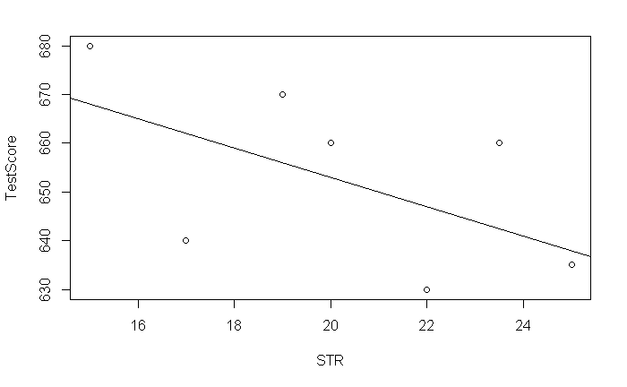

```r
# create a scatterplot of the data
plot(TestScore ~ STR)

# add the systematic relationship to the plot
abline(a = 713, b = -3)
```

In order to account for these differences between observed data and the systematic relationship, we extend our model from above by an error term u which captures additional random effects. Put differently, u accounts for all the differences between the regression line and the actual observed data. Beside pure randomness, these deviations could also arise from measurement errors or, as will be discussed later, could be the consequence of leaving out other factors that are relevant in explaining the dependent variable.

$$TestScore = \beta_0 + \beta_1 \times STR + \text{other factors}$$
$$Y_i = \beta_0 + \beta_1 X_i + u_i.$$

In practice, the intercept β0 and slope β1 of the population regression line are unknown. Therefore, we must employ data to estimate both unknown parameters.

Example1. We want to relate test scores to student-teacher ratios measured in Californian schools. The test score is the district-wide average of reading and math scores for fifth graders. Again, the class size is measured as the number of students divided by the number of teachers (the student-teacher ratio). As for the data, the California School data set (CASchools) comes with an R package called AER, an acronym for Applied Econometrics with R (Kleiber and Zeileis 2020). After installing the package with install.packages(“AER”) and attaching it with library(AER) the data set can be loaded using the function data().

```r
## # install the AER package (once)
## install.packages("AER")
##
## # load the AER package
library(AER)
```

[output not shown]